# ComTel - Analytics diagnostic

**Giancarlo Marchesi**

Marvelytics has been commisioned by ComTel to analyze the evolution of the Peruvian telecommmunications market since 2013, when two strong competitors, SurTel and OrienTel entered the market. ComTels main focus is to increase revenue in a very competititive landscape. Specifically, they want ideas on how to leverage their sales force.

Marvelytics decides to begin from the top, i.e. analyzing the dynamics of the telecom market by market share, product lines and segments. After understanting ComTel's current standing in the market, the next step is to suggest models that can address ComTel's business question.

We will use OSIPTEL's (Peruvian Telecom Regulating Agency) public data for the analysis.

## Competitors

The market is composed mainly of these companies:

- ComTel: Latin-american company. 15 years in the market. Provides mobile, internet, cable, landline and data services.
- PeruTel: European company. 25 yeas in the market. Incumbent. Provides mobile, internet, cable, landline and data services.
- SurTel: Latin-american company. 10 years in the market. Provides mobile, internet, and data services.
- OrientTel: Asian company. 8 years in the market. Provides mobile and internet services.
- QuickTV: American company. Only provides TV services.
- Others: several smaller companies that provide mostly mobile and internet services.

## Market revenue and CAGR

Revenue is expressed in soles (S/.), the Peruvian currency. One dollar fluctuates between 3 and 4 soles during the study period.

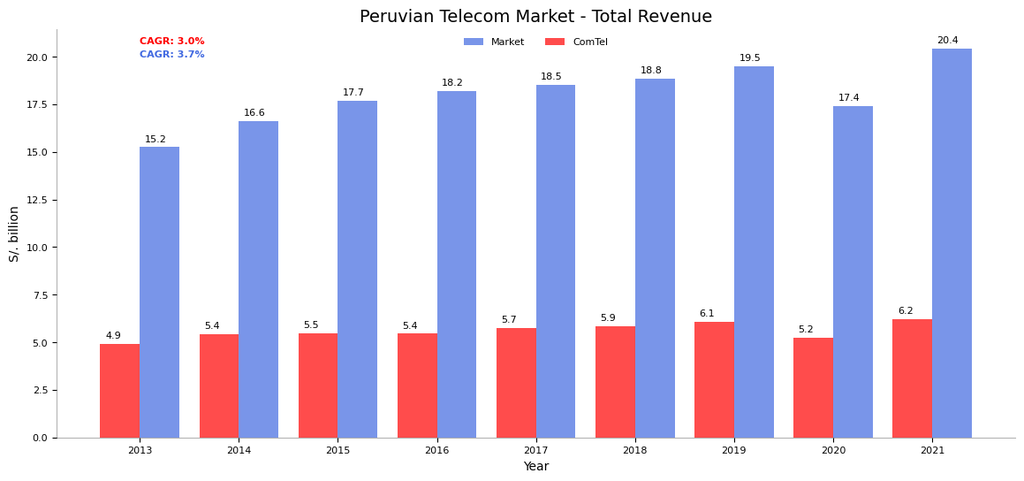

Total market revenue have grown 3.7% in the last 8 years, slightly above the Peruvian economy (3%). The market recovered in 2021, after the pandemic, to continue its positive trajectory. ComTel's total revenue has grown at the same rate as the economy.

Given these numbers, the assumption is that revenue will approximate the country's growth rate. Some product lines will grow rapidly because they are either new technologies or there is still room for further expansion. Other lines are already in a zero-sum game because they compete for the same customers. Finally, some lines are in decline and will eventually disappear due to technological obsolescence.

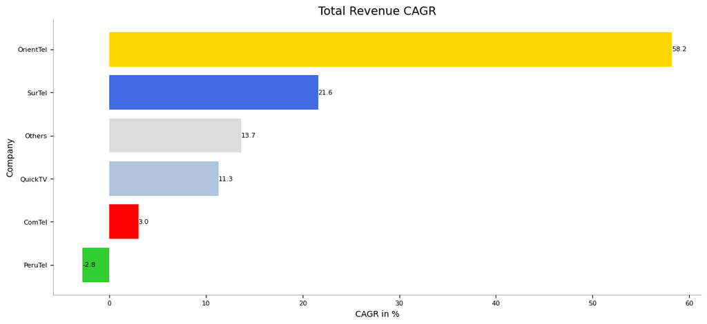

OrientTel and SurTel lead market growth. ComTel's growth is akin to a mature company. PeruTel has contracted.

## Market share

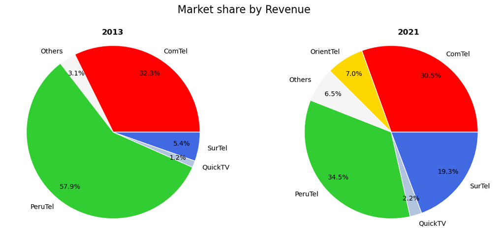

It is a competitive market. ComTel and PeruTel are in defensive mode. ComTel has lost 2% of market share and PeruTel has lost 23% mainly to SurTel and OrientTel. The participation of QuickTel and Others has also grown slightly.

## Product lines

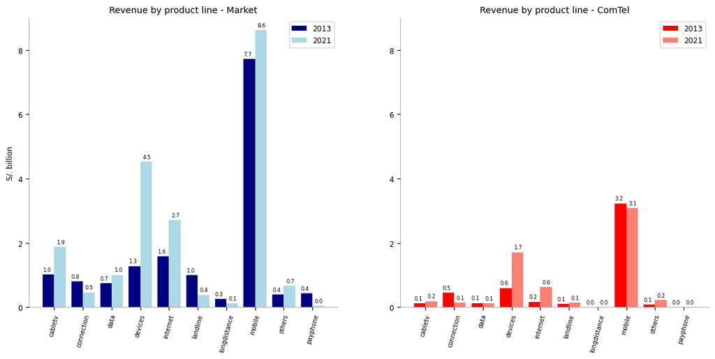

Mobile, devices, internet and cabletv are growing and are the most important in that order. Payphones, landlines and long distance are disappear. ComTels revenue in mobile is stuck.

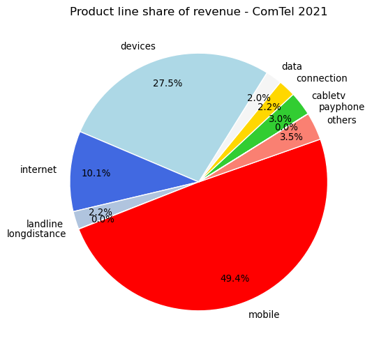

ComTel is well positioned in growing product lines. Mobile and devices are the main income generators, with internet third in importance and growing.

### Market share by product line

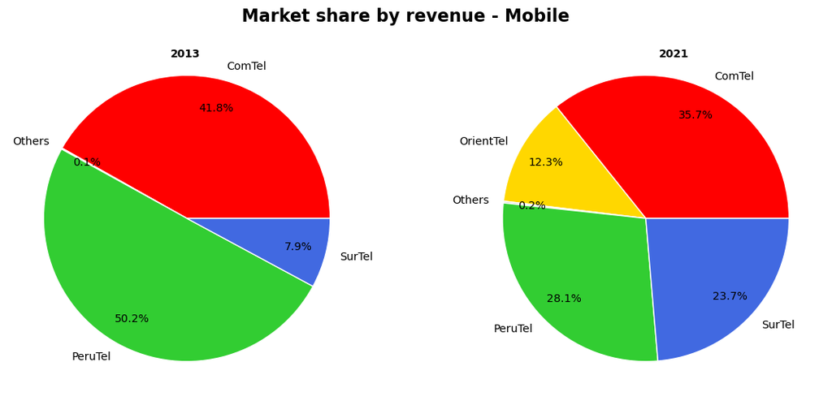

ComTel is the leader in the mobile market by revenue. It has been affected by competition from SurTel and OrientTel, having lost six points of market share. Nevertheless, PeruTel has lost 22 market share points.

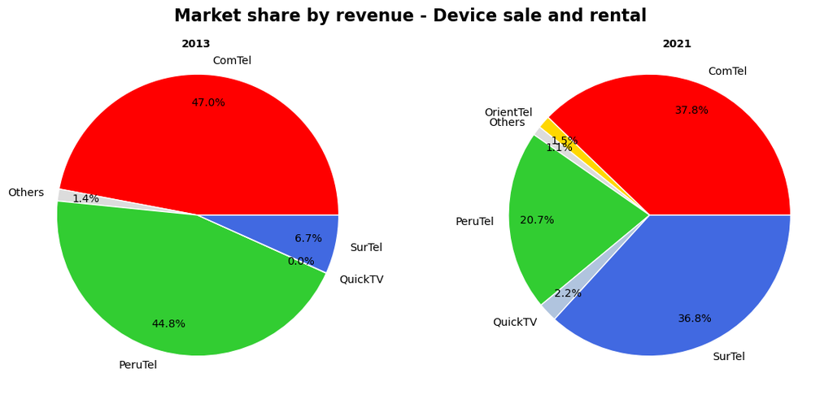

Both ComTel and Perutel have ceded a large stake to SurTel. OrientTel, despite the strong increase in participation in mobile services, does not show a similar increase in device sales.

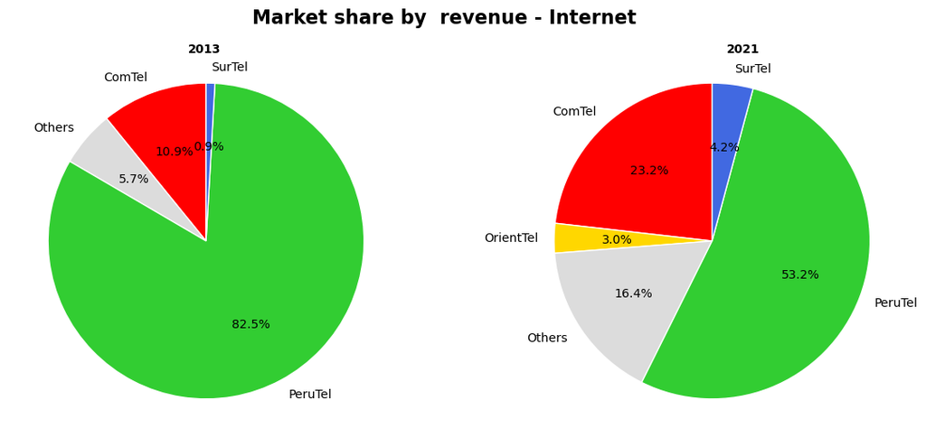

ComTel has more than doubled its share of the internet provider market. SurTel and OrientTel have also grown, but what is more important is the increase in "Others". PeruTel has lost 30 points of the market in only 8 years.

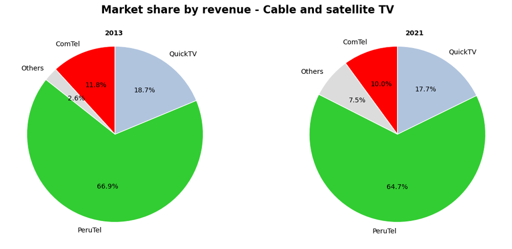

## Mobile phones

Postpaid plans (paid at the end of the month) are two-fold:

- Control plan is a fixed-amount billed at the end of the month. If the user runs out of minutes or data according to their contract, it can add more in increments, similar to the prepaid plan.
- Postpaid plan (classic) is just open to bill whatever you consume after the user runs out of minuets or data at the contract rate.

Prepaid plans are like control plans but are paid upfront by recharging with a credit card or a prepaid phone card.

### Total active mobile lines

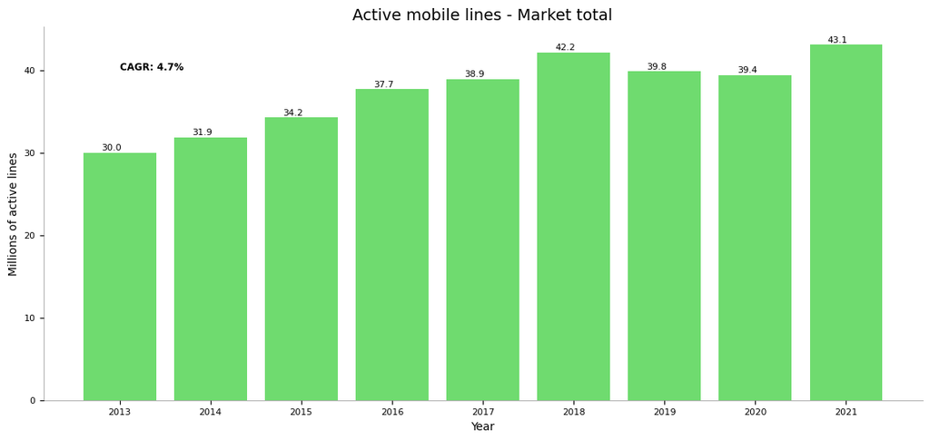

Mobile lines have grown by 4.7% annually for the last 8 years. As of December 2021, the number of active lines was 43.1 million, that is, 1.3 active lines per person.

A UN comparative study from 2018 shows there might still be room for further growth.

In 2021, Peru was at the same level as Argentina 3 years ago and still behind Chile, El Salvador, Uruguay and Costa Rica. If the latter is the north, Peru could reach approximately 58 million lines. If the market continues with the current growth rate, it would reach the level of Costa Rica in 7 years.

However, the GDP per capita of Costa Rica is double that of Peru. It is reasonable to think that growth will slow down or that it will not converge with Costa Rica. Thus, in the next 5 years the market dynamics will become a zero sum game. ComTel must differentiate itself to survive competition from SurTel and OrientTel.

Source: https://es.statista.com/grafico/17011/numero-de-tarjetas-sim-por-persona-en-america-latina/

[figure not shown]

### Mobile market share by company

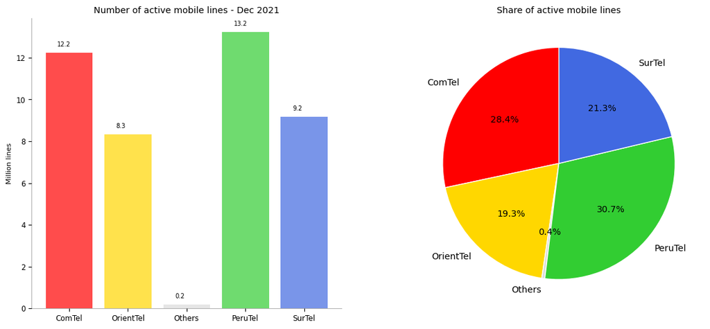

It is a market with four strong competitors, led by PeruTel in number of lines and, as we saw earlier, by ComTel in revenue.

### Size of monthly ticket

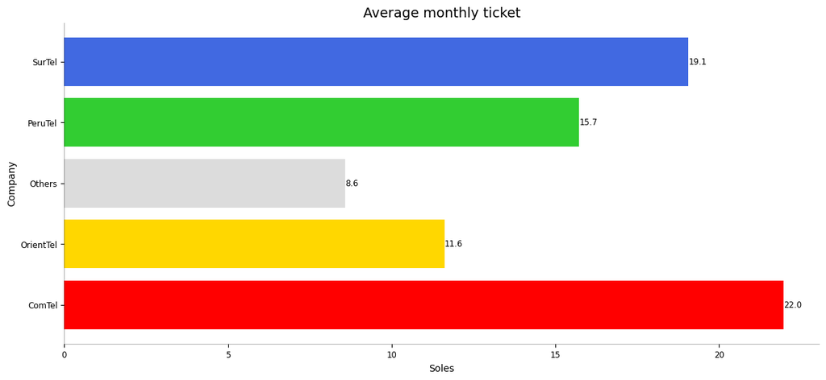

### Number of lines by contract type

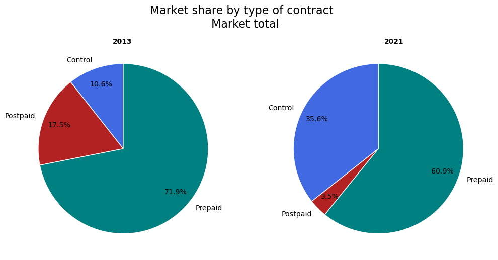

Prepaid lines have lost 11 points in the last 8 years. Control plans have taken over. Traditional postpaid contracts have almost disappeared.

### Market share by type of contract 2021 and company

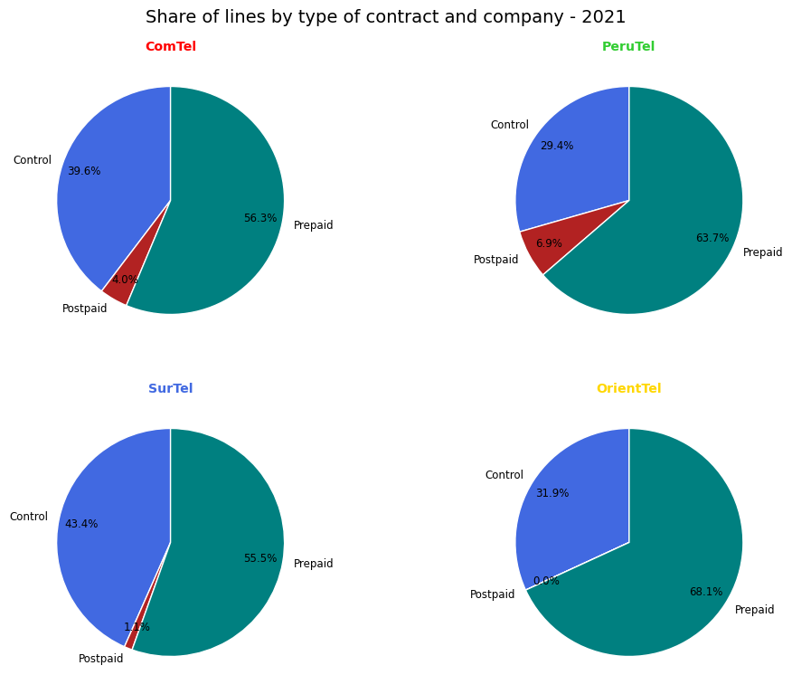

ComTel's share of prepaid is similar to SurTel's, ~55%. OrientTel is mainly oriented to the prepaid market. PeruTel is the intermediate point between both groups.

### Customer service perception

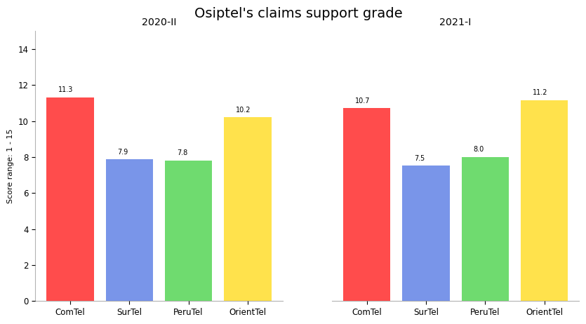

According to data from Osiptel, ComTel and OrientTel have the same quality of customer service and are almost three points above SurTel and PeruTel.

### Activations and terminations

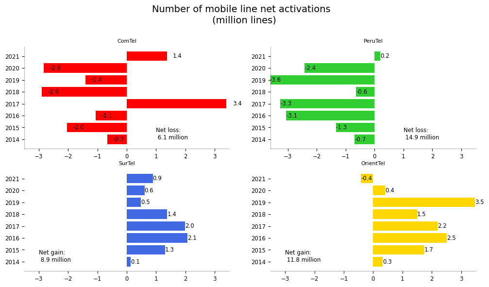

Both new competitors have net gains (activations minus termination, excluding migrations). ComTel lost a total of 6.1 million net lines. PeruTel is the one that has suffered the most from the competition.

### Activations and terminations by contract

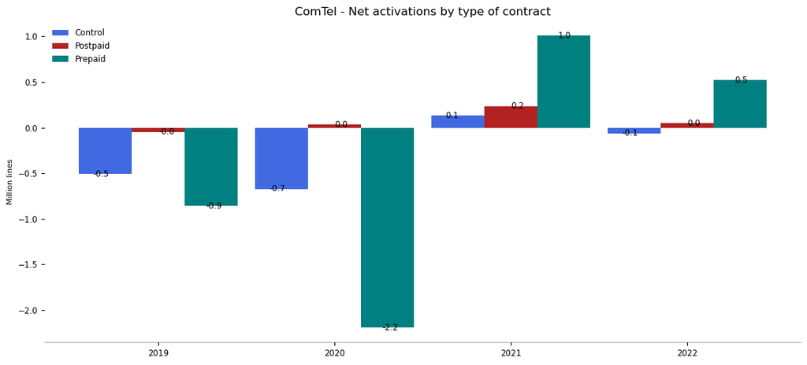

ComTel lost a net of 2.1 million prepaid lines in the last three years and 1.1 million control lines, while it activated 200 thousand postpaid lines. On average, the company has lost 1 million lines per year. However, it seems that it has reacted positively in 2021 and the first half of 2022.

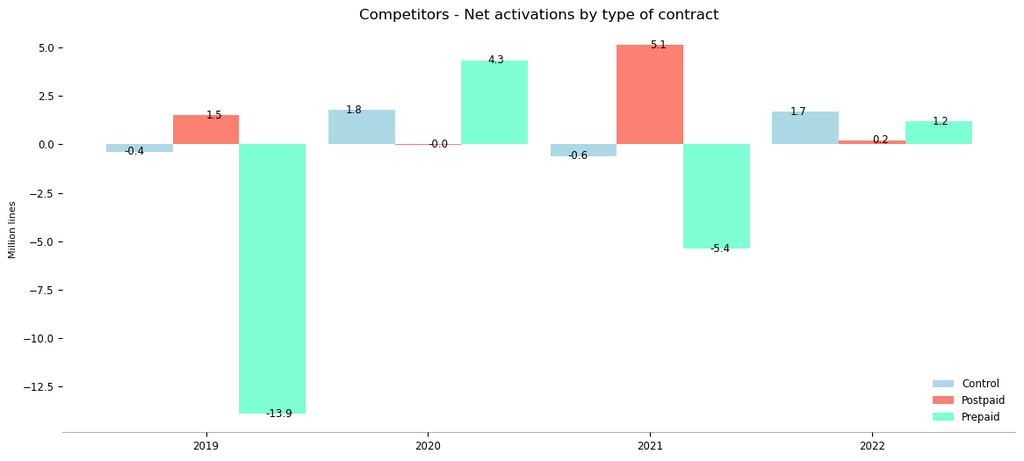

ComTel's competitors lost 15 million net prepaid lines between 2019 and 2021. 75% of this loss is attributable to PeruTel. On the contrary, post payment and control plans increased, thanks to SurTel. The market recovered in the first semester of 2022.

### Carrier switches

Carrier switches are called migrations. The customer keeps the same phone number but operated by a competitor.

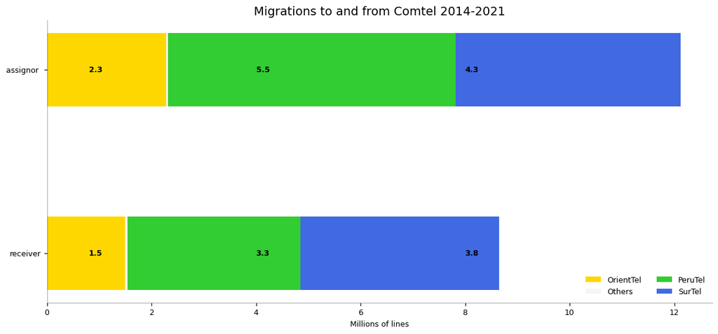

Comtel has received 12.1 million lines from the competition. Almost half have come from PeruTel. On the whole, it received 4 million more migrations than it lost. It has received more than two million net customers from PeruTel.

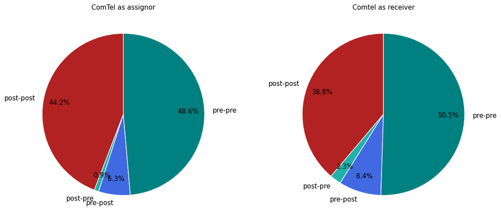

The vast majority (89% and 93%) of the migrations to and from ComTel maintained the same type of contract, be it postpaid to postpaid or prepaid to prepaid.

## Next steps

Marvelitycs' conclusion after the analysis is that ComTel is well positioned against the competition. Since the prepaid market terminates a considerable amount of lines a year, the business hypothesis would be to migrate prepaid customers to the cheapest control plan.

The consultants propose a way to test this hypothesis by using machine learning and A/B tests. The notebook ComTel_clustering continues this line of analysis.